# Tutorium 6

Gruppen 2 und 4  
Samuel Teuber  
propa@teuber.dev  
https://teuber.dev/propa

# Organisatorisches

**Tutorien in der Weihnachtszeit**  
Tutorien am 22. und 23. Dezember finden statt

# Übungsblätter

## Aufgabe 1: Haskell zu $\lambda$-Kalkül

```
fib :: Integer -> Integer
fib 0 = 1
fib 1 = 1
fib n = fib (n-1) + fib (n-2)
```

**Ohne Pattern Matching:**

```
fib n = if n == 0 || n == 1 then 1 else fib (n-1) + fib (n-2)
-- Funktional:
F f n = if n == 0 || n == 1 then 1 else f (n-1) + f (n-2)
```

$$ F = \lambda f.\ \lambda n.\ (\text{isZero}\ (\text{pred}\ n))\ c_1\ (\text{plus}\ (f\ (\text{sub}\ n\ c_1) )\ (f\ (\text{sub}\ n\ c_2) ) )\\ \text{fib} = Y F $$

# Aufgabe 2

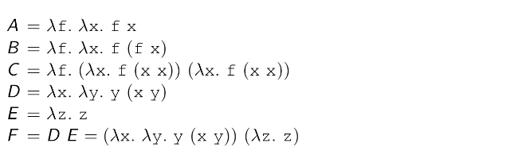

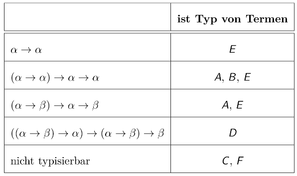

# Aufgabe 3

$$ \frac{ \Gamma \vdash \lambda x.\ \lambda y.\ x:\alpha\rightarrow\beta\rightarrow\alpha\ \ \ \ \ \ \ \ \ \ \ \ \ \ \Gamma,k:\forall\alpha.\forall\beta.\alpha\rightarrow\beta\rightarrow\alpha \vdash k\ a\ (k\ b\ c):\text{int} }{ \Gamma \vdash \textbf{let } k=\lambda x.\ \lambda y.\ x \textbf{ in } k\ a\ (k\ b\ c):\text{int} } $$

Mit Instanziierungen $$ \forall\alpha.\forall\beta.\alpha\rightarrow\beta\rightarrow\alpha \succeq \text{int}\rightarrow\text{bool}\rightarrow\text{int}\\ \forall\alpha.\forall\beta.\alpha\rightarrow\beta\rightarrow\alpha \succeq \text{bool}\rightarrow\text{char}\rightarrow\text{bool}\\ $$

# Aufgabe B.1

$$ (\lambda x.\ x\ x) (\lambda y.\ m\ y\ n)\\ (\lambda x.\ x\ x) (\lambda y.\ f\ y)\\ (\lambda x.\ x\ x) (\lambda y.\ (f\ y)\ y) $$

$$ (\lambda x.\ x\ x) (\lambda y.\ m\ y\ n) \Rightarrow m\ (\lambda y.\ m\ y\ n)\ n\\ (\lambda x.\ x\ x) (\lambda y.\ f\ y) \Rightarrow f\ (\lambda y.f\ y)\\ (\lambda x.\ x\ x) (\lambda y.\ (f\ y)\ y) \Rightarrow f\ (\lambda y. (f\ y)\ y)\ (\lambda y.(f\ y)\ y) $$

# Aufgabe B.2

a) $$ \omega' = (\lambda x.\ x\ x) (\lambda y.\ m\ (y\ y)\ n) $$

$$ \Rightarrow \cdots \Rightarrow m\ (m\ (m\ (\Theta\ \Theta)\ n)\ n)\ n $$

mit $\Theta = (\lambda y.\ m\ (y\ y)\ n) (\lambda y.\ m\ (y\ y)\ n)$

# Aufgabe B.2

b) $$ (\lambda x.\ x\ x) (\lambda y.\lambda n.\ \text{isZero}\ n\ c_1\ ((y\ y)\ (\text{sub}\ n\ c_1)))\ c_2 $$ **Terminiert, wenn wir die richtigen Ausdrücke auswerten!**

$$ \text{count} = (\lambda y.\lambda n.\ \text{isZero}\ n\ c_1\ ((y\ y)\ (\text{sub}\ n\ c_1))) $$$$ (\lambda x.x\ x)\ \text{count}\ c_2\\ \Rightarrow\text{count}\ \text{count}\ c_2\\ \Rightarrow(\lambda y.\lambda n.\ \text{isZero}\ n\ c_1\ ((y\ y)\ (\text{sub}\ n\ c_1)))\ \text{count}\ c_2\\ \Rightarrow\left(\underline{\text{isZero}\ c_2}\right)\ c_1\ ((\text{count}\ \text{count})\ (\text{sub}\ c_2\ c_1))\\ \cdots\\ \Rightarrow c_1 $$

# Aufgabe B.2

c) $$ \omega' = (\lambda x.\ x\ x) (\lambda y.\ m\ (y\ y)\ n) $$ Wie viele Reduktionsschritte kann man auf $\omega'$ anwenden?

# Aufgabe B.3

a) Geben Sie einen Term W an, welcher unter $\beta$-Reduktion nach und nach die Form $f (f (f (f (f (f (\dots))))))$ annimmt

$$ W = (\lambda x.x\ x)(\lambda y. f\ (y\ y)) $$

## Aufgabe B.3

b) Beschreiben Sie, welche Form der Term $X=\lambda f. (\lambda x.x\ x)(\lambda y. f\ (y\ y))$ nach und nach annimmt

$$ (\lambda f. f (f (f (f (f (f (\dots))))))) $$

## Aufgabe B.3

c) Führen Sie einen $\beta$-Reduktionsschritt von $X=\lambda f. (\lambda x.x\ x)(\lambda y. f\ (y\ y))$ aus. Welcher Term entsteht?

$$ X \Rightarrow \lambda f. (\lambda x. f\ (x\ x))(\lambda x. f\ (x\ x)) = Y $$

## Aufgabe B.4

Geben Sie unter Benutzung von $X$ einen Term an, welcher zu $\omega$ reduziert  
$X=\lambda f. (\lambda x.x\ x)(\lambda y. f\ (y\ y))$

$$ X (\lambda x. x) \Rightarrow (\lambda x.x\ x)(\lambda y. (\lambda x. x)\ (y\ y)) \Rightarrow (\lambda x.x\ x)(\lambda x.x\ x) $$

# Das wars erstmal zum $\lambda$

**Fragen?**

# Prolog

Logische Programmierung

- **Atome**: Beginnend mit Kleinbuchstaben `fritz`
- **Zahlen**: Wie üblich `1,2,3,4.2`
- **Variablen**: Beginnend mit Großbuchstaben oder Unterstrich `X, _X`
- **Funktor**: Zusammensetzung `mensch(fritz)`, `alter(fritz, 17)`
  - Atom = Nullstelliger Funktor
  - Funktor -> Prädikat: Jedem Funktor werden Wahrheitswerte zugeordnet

# Exkurs: Hornklauseln

Flashback GBI: Aussagenlogik

Disjunktionen mit höchstens einem positiven Literal $$ \neg x_1 \lor \neg x_2 \lor \neg x_3 \lor \neg x_4 \lor y $$

Kann man dann auch schreiben als: $$ x_1 \land x_2 \land x_3 \land x_4 \implies y $$

**Horn-Klauseln können in Polynomialzeit auf Erfüllbarkeit getestet werden!**

# Exkurs: Hornklauseln

Typen von Horn-Klauseln:

  ```
  mensch(sokrates).
  nichtChuckNorris(sokrates).
  ```

- Definite Hornklausel:  
  $\neg x_1 \lor \neg x_2 \lor y \ \ \ \ \ \equiv \ \ \ \ \ x_1 \land x_2 \implies y$

  ```
  sterblich(X) :- mensch(X), nichtChuckNorris(X).
  ```

  Das X ist hier zu verstehen als $\text{mensch}(X)\land\text{nichtChuckNorris}(X) \implies \text{sterblich}(X)$
- Zielklausel:  
  $\neg x_1 \lor \neg x_2 \ \ \ \ \ \equiv \ \ \ \ \ x_1 \land x_2 \implies 0$  
  Prolog Query:

  ```
  ?- mensch(sokrates), sterblich(sokrates).
  ```

  **Details in Formale Systeme**

```python
liebt(fritz,fische). %Atome: fritz und fische, Funktor/Prädikat: liebt
liebt(hans,inge).
liebt(inge,fritz).
liebt(julia,fritz).
liebt(anna,X) :- liebt(julia,X). % liebt(anna,X) wahr, wenn liebt(julia,X) wahr

QUERYSTART
liebt(Y,fritz)
QUERYEND
```

Regeln werden wie bei Haskell List-Comprehensions reerfüllt: **Jede mögliche Kombination** wird durchgespielt

**Prolog mit SWI Prolog online**  
[SWISH](https://swish.swi-prolog.org/)

```
swish.swi-prolog.org
```

# Übung

1. John ist der Vater von Peter
2. Peter ist der Vater von Nick
3. Wenn X der Vater von Y ist und Y der Vater von Z ist, dann ist X der Großvater von Z
4. Wer ist der Großvater von Nick?

```python
% ???

QUERYSTART
grandfather(G,nick)
QUERYEND
```

# Backtracking

Mit swipl

# Arithmetik

```python
formula(A,B,C,R) :- R is A+(A*B)-C-(C/A).

QUERYSTART
formula(1,2,3,R)
QUERYEND
```

Zusätzlich: `<,<=,>=,>,=:=,=\=`

# Fibonacci-Zahlen

```python
fib(0,0).
%???

QUERYSTART
fib(8,R)
QUERYEND
```

# Listen

- `[|]` als Cons-Operator

- ```
  member(X,[X|R]).
  member(X,[Y|R]) :- member(X,R).
  ```

- ```
  append([],L,L).
  append([X|R],L,[X|T]) :- append(R,L,T).
  ```

- ```
  rev([],[]).
  rev([X|R],Y) :- rev(R,Y1),append(Y1,[X],Y).
  ```

```python
startsWith1([X|_]) :- X is 1.


QUERYSTART
startsWith1([Z,2,3])
QUERYEND
```

# Nützliche Prädikate

- `not(X)`: Negation von `X`: Wie? -> Nächste Woche!
- `atom(X)`: Ist `X` mit Atom instanziiert?
- `integer(X)`: Ist `X` mit Ganzzahl instanziiert?
- `float(X)`: Ist `X` mit Gleitkommazahl instanziiert?
- `atomic(X)`: Ist `X` mit Atom oder Zahl instanziiert?

# Übungsaufgabe: Vorfahren

```python
father(samuel, john).
father(john,peter).
father(peter, nick).
father(luke, ann).
father(john, guy).
mother(laura, peter).
mother(sara,ann).
mother(ann, nick).
mother(laura, guy).

ancestor(X,X).
ancestor(X,Y) :- father(X,Z), ancestor(Z,Y).
ancestor(X,Y) :- mother(X,Z), ancestor(Z,Y).

%Does list L contain ancestors?
%containsAncestors(...,...):-...
%...

% Further predicates
parent(X,Y):- %...
sibling(X,Y):- %....
auntOrUncle(X,Y):- %...
```

```
ERROR: /tmp/tmpt4jdm2ug/code.pl:31:23: Syntax error: Unexpected end of file
```

# Splits

```
splits(L,Res)
```

Bei **Reerfüllung**: Alle möglichen Zerlegungen von `L` in `Res` der Form `(L1,L2)`

```python
%???

QUERYSTART
splits([1,2,3,4,5],R)
QUERYEND
```